# Sanger Variants in Diversity Outbred Mice

DMG

9/23/2021

Using other scripts, I intersected the Ensembl genes with the [Sanger Mouse Genomes Project](https://www.sanger.ac.uk/data/mouse-genomes-project/) SNPs, indels, and structural variants to tally the total number of each, the number in each gene, and the number of each type of variant. I selected SNPs that passed the Sanger quality filter and had no missing data for any strain. This only includes data for chromosomes 1 - 19 and X.

Genome: GRCm38

Ensembl: 97

Sanger: version 7

# Total Variants.

```r
total_snps   = read.csv(file.path(base_dir, 'total_snps.csv')) %>%
                 mutate(chr = factor(chr, levels = c(1:19, 'X'))) %>%
                 arrange(chr)
total_indels = read.csv(file.path(base_dir, 'total_indels.csv')) %>%
                 mutate(chr = factor(chr, levels = c(1:19, 'X'))) %>%
                 arrange(chr)
```

There were a total of 38,119,670 SNPs distributed across the chromosomes as follows.

```r
kable(total_snps, align = 'c', caption = 'Total SNPs by Chromosome')
```

Total SNPs by Chromosome

| chr | count |
| --- | --- |
| 1 | 2940052 |
| 2 | 2538713 |
| 3 | 2502027 |
| 4 | 2288636 |
| 5 | 2332070 |
| 6 | 2242696 |
| 7 | 2177967 |
| 8 | 1909800 |
| 9 | 1791133 |
| 10 | 2011881 |
| 11 | 1814818 |
| 12 | 1926250 |
| 13 | 1854259 |
| 14 | 1719166 |
| 15 | 1521423 |
| 16 | 1345383 |
| 17 | 1420982 |
| 18 | 1400027 |
| 19 | 925970 |
| X | 1456417 |

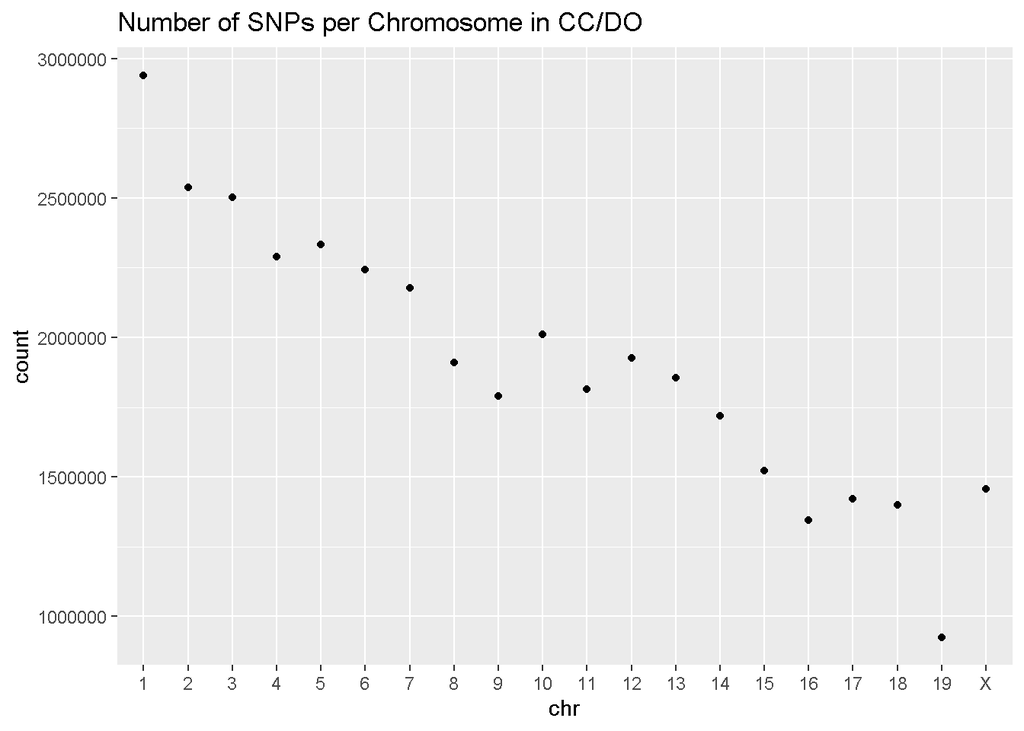

```r
total_snps %>%
  ggplot(aes(chr, count)) +
  geom_point() +
  labs(title = 'Number of SNPs per Chromosome in CC/DO')
```

There were a total of 7,336,412 Indels distributed across the chromosomes as follows.

```r
kable(total_indels, align = 'c', caption = 'Total Indels by Chromosome')
```

Total Indels by Chromosome

| chr | count |
| --- | --- |
| 1 | 564606 |
| 2 | 514119 |
| 3 | 467504 |
| 4 | 432089 |
| 5 | 456093 |
| 6 | 403958 |
| 7 | 389631 |
| 8 | 366145 |
| 9 | 362439 |
| 10 | 388919 |
| 11 | 381456 |
| 12 | 354720 |
| 13 | 353385 |
| 14 | 322808 |
| 15 | 292729 |
| 16 | 255935 |
| 17 | 275583 |
| 18 | 273618 |
| 19 | 183936 |
| X | 296739 |

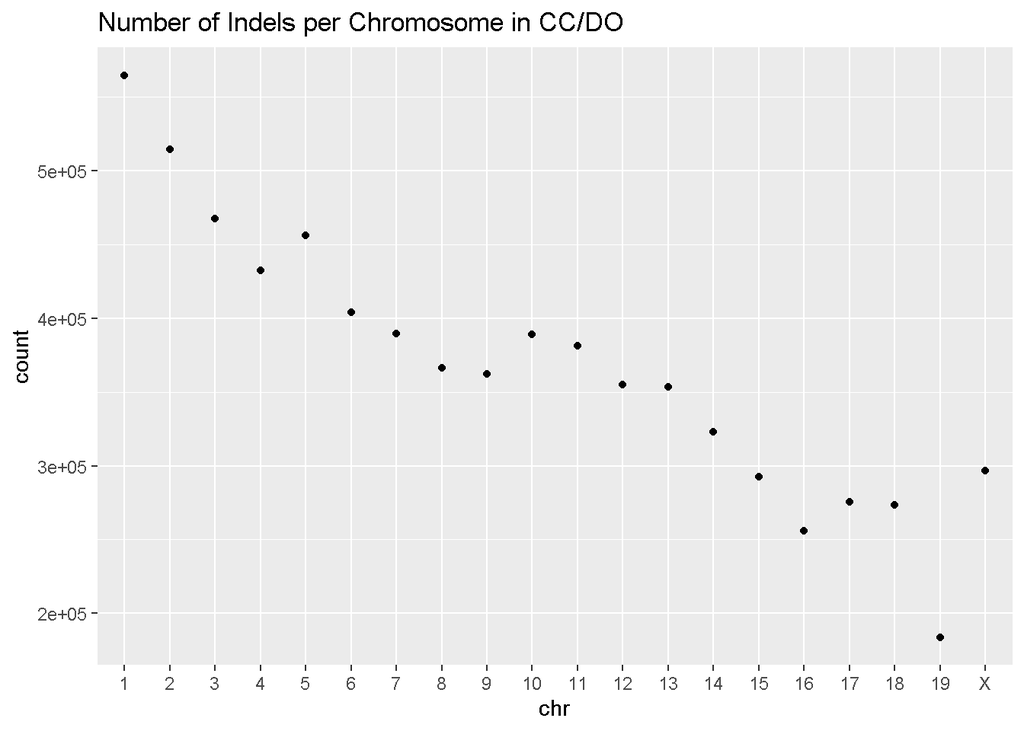

```r
total_indels %>%
  ggplot(aes(chr, count)) +
  geom_point() +
  labs(title = 'Number of Indels per Chromosome in CC/DO')
```

# Variants in Exons

## SNPs in Exons

I intersected the SNPs with any part of any exon, including the untranslated regions. I used anything defined as an ‘exon’ in the [Ensembl 97 database](https://support.bioconductor.org/p/122708/).

```r
snps = readRDS(file.path(base_dir, 'snps_by_gene.rds'))
snps = snps %>%
         rename(chr = seqnames) %>%
         mutate(chr = factor(chr, levels = c(1:19, 'X')))
total_biotypes = snps %>%
                   count(gene_biotype)
snps_by_biotype = snps %>%
                    filter(num_variants > 0) %>%
                    count(gene_biotype)
snps_by_chr = snps %>%
                filter(num_variants > 0) %>%
                group_by(chr) %>%
                summarize(num_snps = sum(num_variants))
genes_by_chr = snps %>%
                filter(num_variants > 0) %>%
                count(gene_id)
```

```r
kable(snps_by_chr, align = 'c', caption = 'SNPs in Exons')
```

SNPs in Exons

| chr | num_snps |
| --- | --- |
| 1 | 143985 |
| 2 | 132656 |
| 3 | 110053 |
| 4 | 92018 |
| 5 | 139711 |
| 6 | 118559 |
| 7 | 192969 |
| 8 | 85080 |
| 9 | 108464 |
| 10 | 98750 |
| 11 | 106846 |
| 12 | 83551 |
| 13 | 90851 |
| 14 | 70938 |
| 15 | 63670 |
| 16 | 53423 |
| 17 | 109888 |
| 18 | 59507 |
| 19 | 58144 |
| X | 42183 |

There were 53881 features in this Ensembl build. 47710 features (89%) contained SNPs in their exons.

The SNPs break down by biotype as follows.

```r
full_join(total_biotypes, snps_by_biotype, by = 'gene_biotype') %>%
  rename(total_genes     = n.x,
         genes_with_snps = n.y) %>%
  mutate(pct_with_snps   = genes_with_snps / total_genes * 100) %>%
  kable(digits = 2, align = 'c', caption = 'SNPs in Exons by Gene Biotype')
```

SNPs in Exons by Gene Biotype

| gene_biotype | total_genes | genes_with_snps | pct_with_snps |
| --- | --- | --- | --- |
| IG_C_gene | 13 | 13 | 100.00 |
| IG_C_pseudogene | 1 | 1 | 100.00 |
| IG_D_gene | 19 | 13 | 68.42 |
| IG_D_pseudogene | 3 | 3 | 100.00 |
| IG_J_gene | 14 | 11 | 78.57 |
| IG_LV_gene | 4 | 3 | 75.00 |
| IG_pseudogene | 2 | 1 | 50.00 |
| IG_V_gene | 218 | 205 | 94.04 |
| IG_V_pseudogene | 158 | 127 | 80.38 |
| lncRNA | 9655 | 9027 | 93.50 |
| miRNA | 2196 | 1072 | 48.82 |
| misc_RNA | 562 | 413 | 73.49 |
| polymorphic_pseudogene | 86 | 83 | 96.51 |
| processed_pseudogene | 9872 | 8724 | 88.37 |
| protein_coding | 21638 | 20456 | 94.54 |
| pseudogene | 60 | 52 | 86.67 |
| ribozyme | 22 | 19 | 86.36 |
| rRNA | 345 | 208 | 60.29 |
| scaRNA | 51 | 34 | 66.67 |
| scRNA | 1 | 1 | 100.00 |
| snoRNA | 1507 | 922 | 61.18 |
| snRNA | 1382 | 904 | 65.41 |
| sRNA | 2 | 1 | 50.00 |
| TEC | 3232 | 3034 | 93.87 |
| TR_C_gene | 8 | 8 | 100.00 |
| TR_D_gene | 4 | 1 | 25.00 |
| TR_J_gene | 70 | 31 | 44.29 |
| TR_J_pseudogene | 10 | 4 | 40.00 |
| TR_V_gene | 144 | 128 | 88.89 |
| TR_V_pseudogene | 34 | 32 | 94.12 |
| transcribed_processed_pseudogene | 296 | 278 | 93.92 |
| transcribed_unitary_pseudogene | 22 | 20 | 90.91 |
| transcribed_unprocessed_pseudogene | 237 | 219 | 92.41 |
| translated_unprocessed_pseudogene | 1 | 1 | 100.00 |
| unitary_pseudogene | 43 | 42 | 97.67 |
| unprocessed_pseudogene | 1969 | 1619 | 82.22 |

## Indels in Exons

This intersects the variants with any part of any exon, including the untranslated regions.

```r
indels = readRDS(file.path(base_dir, 'indels_by_gene.rds'))
indels = indels %>%
         rename(chr = seqnames) %>%
         mutate(chr = factor(chr, levels = c(1:19, 'X')))
total_biotypes = indels %>%
                  count(gene_biotype)
indels_by_biotype = indels %>%
                    filter(num_variants > 0) %>%
                    count(gene_biotype)
indels_by_chr = indels %>%
                  filter(num_variants > 0) %>%
                  group_by(chr) %>%
                  summarize(num_indels = sum(num_variants))
genes_by_chr = snps %>%
                 filter(num_variants > 0) %>%
                 count(gene_id)
```

```r
kable(indels_by_chr, align = 'c', caption = 'Indels in Exons')
```

Indels in Exons

| chr | num_indels |
| --- | --- |
| 1 | 22393 |
| 2 | 20183 |
| 3 | 17845 |
| 4 | 12648 |
| 5 | 21821 |
| 6 | 16787 |
| 7 | 24440 |
| 8 | 13411 |
| 9 | 17053 |
| 10 | 14656 |
| 11 | 15100 |
| 12 | 11664 |
| 13 | 13646 |
| 14 | 9937 |
| 15 | 9295 |
| 16 | 7332 |
| 17 | 14230 |
| 18 | 8824 |
| 19 | 8305 |
| X | 6424 |

There were 53,881 features in this Ensembl build. 34365 features (63.7794399%) contained indels in their exons. ‘Exon’ is defined as Ensembl defines it in their annotation.

The indels break down by biotype as follows.

```r
full_join(total_biotypes, indels_by_biotype, by = 'gene_biotype') %>%
  rename(total_genes     = n.x,
         genes_with_indels = n.y) %>%
  mutate(pct_with_indels   = genes_with_indels / total_genes * 100) %>%
  kable(digits = 2, align = 'c', caption = 'Indels in Exons by Gene Biotype')
```

Indels in Exons by Gene Biotype

| gene_biotype | total_genes | genes_with_indels | pct_with_indels |
| --- | --- | --- | --- |
| IG_C_gene | 13 | 8 | 61.54 |
| IG_C_pseudogene | 1 | 1 | 100.00 |
| IG_D_gene | 19 | 2 | 10.53 |
| IG_D_pseudogene | 3 | NA | NA |
| IG_J_gene | 14 | NA | NA |
| IG_LV_gene | 4 | NA | NA |
| IG_pseudogene | 2 | NA | NA |
| IG_V_gene | 218 | 46 | 21.10 |
| IG_V_pseudogene | 158 | 67 | 42.41 |
| lncRNA | 9655 | 6978 | 72.27 |
| miRNA | 2196 | 336 | 15.30 |
| misc_RNA | 562 | 161 | 28.65 |
| polymorphic_pseudogene | 86 | 65 | 75.58 |
| processed_pseudogene | 9872 | 4797 | 48.59 |
| protein_coding | 21638 | 17402 | 80.42 |
| pseudogene | 60 | 31 | 51.67 |
| ribozyme | 22 | 6 | 27.27 |
| rRNA | 345 | 30 | 8.70 |
| scaRNA | 51 | 12 | 23.53 |
| scRNA | 1 | 1 | 100.00 |
| snoRNA | 1507 | 212 | 14.07 |
| snRNA | 1382 | 256 | 18.52 |
| sRNA | 2 | NA | NA |
| TEC | 3232 | 2764 | 85.52 |
| TR_C_gene | 8 | 5 | 62.50 |
| TR_D_gene | 4 | 1 | 25.00 |
| TR_J_gene | 70 | 1 | 1.43 |
| TR_J_pseudogene | 10 | 2 | 20.00 |
| TR_V_gene | 144 | 20 | 13.89 |
| TR_V_pseudogene | 34 | 12 | 35.29 |
| transcribed_processed_pseudogene | 296 | 206 | 69.59 |
| transcribed_unitary_pseudogene | 22 | 19 | 86.36 |
| transcribed_unprocessed_pseudogene | 237 | 160 | 67.51 |
| translated_unprocessed_pseudogene | 1 | 1 | 100.00 |
| unitary_pseudogene | 43 | 25 | 58.14 |
| unprocessed_pseudogene | 1969 | 738 | 37.48 |

# Variants in Coding Sequences

## SNPS in Coding Sequences

This intersects the variants with any part of a CDS, as defined in the Ensembl data.

```r
snps = readRDS(file.path(base_dir, 'snps_by_cds.rds'))
snps = snps %>%
         rename(chr = seqnames) %>%
         mutate(chr = factor(chr, levels = c(1:19, 'X')))
total_biotypes = snps %>%
                count(gene_biotype)
snps_by_biotype = snps %>%
                    filter(num_variants > 0) %>%
                    count(gene_biotype)
snps_by_chr = snps %>%
                filter(num_variants > 0) %>%
                group_by(chr) %>%
                summarize(count = sum(num_variants, na.rm = TRUE))
```

There were 272,667 SNPs in CDS, broken down by chromosome as follows:

```r
kable(snps_by_chr, align = 'c', caption = 'Number of SNPs in CDS per Chromosome')
```

Number of SNPs in CDS per Chromosome

| chr | count |
| --- | --- |
| 1 | 18711 |
| 2 | 19837 |
| 3 | 12201 |
| 4 | 16017 |
| 5 | 17374 |
| 6 | 15413 |
| 7 | 27063 |
| 8 | 10743 |
| 9 | 14071 |
| 10 | 12198 |
| 11 | 20879 |
| 12 | 12003 |
| 13 | 10648 |
| 14 | 9585 |
| 15 | 8429 |
| 16 | 7363 |
| 17 | 16306 |
| 18 | 8896 |
| 19 | 8635 |
| X | 6295 |

There were 53,881 features in this Ensembl build. 20230 features (37.5457026%) contained SNPs in their CDS. ‘CDS’ is defined as Ensembl defines it in their annotation.

The SNPs break down by biotype as follows.

```r
full_join(total_biotypes, snps_by_biotype, by = 'gene_biotype') %>%
  rename(total_genes     = n.x,
         genes_with_snps = n.y) %>%
  mutate(pct_with_snps   = genes_with_snps / total_genes * 100) %>%
  kable(digits = 2, align = 'c', caption = 'SNPs in CDS by Gene Biotype')
```

SNPs in CDS by Gene Biotype

| gene_biotype | total_genes | genes_with_snps | pct_with_snps |
| --- | --- | --- | --- |
| IG_C_gene | 13 | 13 | 100.00 |
| IG_C_pseudogene | 1 | NA | NA |
| IG_D_gene | 19 | 13 | 68.42 |
| IG_D_pseudogene | 3 | NA | NA |
| IG_J_gene | 14 | 11 | 78.57 |
| IG_LV_gene | 4 | 3 | 75.00 |
| IG_pseudogene | 2 | NA | NA |
| IG_V_gene | 218 | 205 | 94.04 |
| IG_V_pseudogene | 158 | NA | NA |
| lncRNA | 9655 | NA | NA |
| miRNA | 2196 | NA | NA |
| misc_RNA | 562 | NA | NA |
| polymorphic_pseudogene | 86 | 81 | 94.19 |
| processed_pseudogene | 9872 | NA | NA |
| protein_coding | 21638 | 19738 | 91.22 |
| pseudogene | 60 | NA | NA |
| ribozyme | 22 | NA | NA |
| rRNA | 345 | NA | NA |
| scaRNA | 51 | NA | NA |
| scRNA | 1 | NA | NA |
| snoRNA | 1507 | NA | NA |
| snRNA | 1382 | NA | NA |
| sRNA | 2 | NA | NA |
| TEC | 3232 | NA | NA |
| TR_C_gene | 8 | 8 | 100.00 |
| TR_D_gene | 4 | 1 | 25.00 |
| TR_J_gene | 70 | 31 | 44.29 |
| TR_J_pseudogene | 10 | NA | NA |
| TR_V_gene | 144 | 126 | 87.50 |
| TR_V_pseudogene | 34 | NA | NA |
| transcribed_processed_pseudogene | 296 | NA | NA |
| transcribed_unitary_pseudogene | 22 | NA | NA |
| transcribed_unprocessed_pseudogene | 237 | NA | NA |
| translated_unprocessed_pseudogene | 1 | NA | NA |
| unitary_pseudogene | 43 | NA | NA |
| unprocessed_pseudogene | 1969 | NA | NA |

## Indels in Coding Sequences

This intersects the variants with any part of a CDS, as defined in the Ensembl data.

```r
indels = readRDS(file.path(base_dir, 'indels_by_cds.rds'))
indels = indels %>%
           rename(chr = seqnames) %>%
           mutate(chr = factor(chr, levels = c(1:19, 'X')))
total_biotypes = indels %>%
                   count(gene_biotype)
indels_by_biotype = indels %>%
                      filter(num_variants > 0) %>%
                      count(gene_biotype)
indels_by_chr = indels %>%
                  group_by(chr) %>%
                  summarize(count = sum(num_variants, na.rm = TRUE))
```

There were 5,260 Indels in CDS, broken down by chromosome as follows:

```r
kable(indels_by_chr, align = 'c', caption = 'Number of Indels in CDS per Chromosome')
```

Number of Indels in CDS per Chromosome

| chr | count |
| --- | --- |
| 1 | 368 |
| 2 | 417 |
| 3 | 292 |
| 4 | 281 |
| 5 | 321 |
| 6 | 283 |
| 7 | 493 |
| 8 | 227 |
| 9 | 278 |
| 10 | 259 |
| 11 | 388 |
| 12 | 193 |
| 13 | 192 |
| 14 | 183 |
| 15 | 150 |
| 16 | 123 |
| 17 | 307 |
| 18 | 160 |
| 19 | 155 |
| X | 190 |

There were 53,881 features in this Ensembl build. 3387 features (6.2860749%) contained Indels in their CDS. ‘CDS’ is defined as Ensembl defines it in their annotation.

The indels break down by biotype as follows.

```r
full_join(total_biotypes, indels_by_biotype, by = 'gene_biotype') %>%
  rename(total_genes     = n.x,
         genes_with_indels = n.y) %>%
  mutate(pct_with_indels   = genes_with_indels / total_genes * 100) %>%
  kable(digits = 2, align = 'c', caption = 'Indels in CDS by Gene Biotype')
```

Indels in CDS by Gene Biotype

| gene_biotype | total_genes | genes_with_indels | pct_with_indels |
| --- | --- | --- | --- |
| IG_C_gene | 13 | 4 | 30.77 |
| IG_C_pseudogene | 1 | NA | NA |
| IG_D_gene | 19 | 2 | 10.53 |
| IG_D_pseudogene | 3 | NA | NA |
| IG_J_gene | 14 | NA | NA |
| IG_LV_gene | 4 | NA | NA |
| IG_pseudogene | 2 | NA | NA |
| IG_V_gene | 218 | 44 | 20.18 |
| IG_V_pseudogene | 158 | NA | NA |
| lncRNA | 9655 | NA | NA |
| miRNA | 2196 | NA | NA |
| misc_RNA | 562 | NA | NA |
| polymorphic_pseudogene | 86 | 50 | 58.14 |
| processed_pseudogene | 9872 | NA | NA |
| protein_coding | 21638 | 3271 | 15.12 |
| pseudogene | 60 | NA | NA |
| ribozyme | 22 | NA | NA |
| rRNA | 345 | NA | NA |
| scaRNA | 51 | NA | NA |
| scRNA | 1 | NA | NA |
| snoRNA | 1507 | NA | NA |
| snRNA | 1382 | NA | NA |
| sRNA | 2 | NA | NA |
| TEC | 3232 | NA | NA |
| TR_C_gene | 8 | 2 | 25.00 |
| TR_D_gene | 4 | 1 | 25.00 |
| TR_J_gene | 70 | 1 | 1.43 |
| TR_J_pseudogene | 10 | NA | NA |
| TR_V_gene | 144 | 12 | 8.33 |
| TR_V_pseudogene | 34 | NA | NA |
| transcribed_processed_pseudogene | 296 | NA | NA |
| transcribed_unitary_pseudogene | 22 | NA | NA |
| transcribed_unprocessed_pseudogene | 237 | NA | NA |
| translated_unprocessed_pseudogene | 1 | NA | NA |
| unitary_pseudogene | 43 | NA | NA |
| unprocessed_pseudogene | 1969 | NA | NA |

# Variants by Consequence

There are 21 different variant consequences in the Sanger files. The sum of the variant consequences of each type will be greater than the total number of variants because a single variant may have more than one consequence, and so will be double-counted. These values were derived from the ‘consequence’ part of the Sanger VCF and the totals differ from the numbers above.

## SNPs by Consequence

```r
snps = readRDS(file.path(base_dir, 'snps_by_type.rds'))
```

```r
genes_by_type = snps %>%
                 select(-(seqnames:gene_biotype)) %>%
                 pivot_longer(cols = -gene_id, names_to = 'consequence', values_to = 'count') %>%
                 drop_na() %>%
                 count(consequence) %>%
                 rename(num_genes = n)

csq_tbl = snps %>%
            pivot_longer(cols = intergenic_variant:incomplete_terminal_codon_variant,
                         names_to = 'consequence', values_to = 'count') %>%
            group_by(consequence) %>%
            summarize(num_snps = sum(count, na.rm = TRUE)) %>%
            full_join(genes_by_type, by = 'consequence') %>%
            filter(consequence != 'NA')

kable(csq_tbl, digits = 2, align = 'c', caption = 'Number of SNPs and Genes by Consequence')
```

Number of SNPs and Genes by Consequence

| consequence | num_snps | num_genes |
| --- | --- | --- |
| 3_prime_UTR_variant | 442936 | 18641 |
| 5_prime_UTR_variant | 82941 | 15430 |
| coding_sequence_variant | 141 | 132 |
| downstream_gene_variant | 5875128 | 51552 |
| incomplete_terminal_codon_variant | 85 | 77 |
| intergenic_variant | 16635654 | 20 |
| intron_variant | 25268996 | 30496 |
| missense_variant | 112672 | 16510 |
| NMD_transcript_variant | 2691099 | 4346 |
| non_coding_transcript_exon_variant | 872815 | 38441 |
| non_coding_transcript_variant | 8716951 | 22095 |
| splice_acceptor_variant | 1269 | 1145 |
| splice_donor_variant | 2067 | 1749 |
| splice_region_variant | 53832 | 16473 |
| start_lost | 219 | 193 |
| stop_gained | 1401 | 1037 |
| stop_lost | 321 | 300 |
| stop_retained_variant | 174 | 169 |
| synonymous_variant | 177681 | 19456 |
| upstream_gene_variant | 5455302 | 51533 |
| mature_miRNA_variant | NA | 261 |

As expected, most of the SNPs fall outside of coding regions. There are 112672 missense variants in 16510 genes.

```r
gene_ct = snps %>%
            select(gene_id, gene_biotype, `3_prime_UTR_variant`, `5_prime_UTR_variant`, missense_variant,
                   synonymous_variant, coding_sequence_variant, starts_with('start'), starts_with('stop')) %>%
            filter(gene_biotype == 'protein_coding') %>%
            pivot_longer(cols = `3_prime_UTR_variant`:stop_retained_variant,
                         names_to = 'type', values_to = 'count') %>%
            group_by(gene_id) %>%
            summarize(num_snps = sum(count, na.rm = TRUE)) %>%
            filter(num_snps > 0)
```

## Indels by Consequence

```r
indels = readRDS(file.path(base_dir, 'indels_by_type.rds'))
```

```r
genes_by_type = indels %>%
                 select(-(seqnames:gene_biotype)) %>%
                 pivot_longer(cols = -gene_id, names_to = 'consequence', values_to = 'count') %>%
                 drop_na() %>%
                 count(consequence) %>%
                 rename(num_genes = n)

csq_tbl = indels %>%
            pivot_longer(cols = intergenic_variant:incomplete_terminal_codon_variant,
                         names_to = 'consequence', values_to = 'count') %>%
            group_by(consequence) %>%
            summarize(num_indels = sum(count, na.rm = TRUE)) %>%
            full_join(genes_by_type, by = 'consequence') %>%
            filter(consequence != 'NA')

kable(csq_tbl, digits = 2, align = 'c', caption = 'Number of Indels and Genes by Consequence')
```

Number of Indels and Genes by Consequence

| consequence | num_indels | num_genes |
| --- | --- | --- |
| 3_prime_UTR_variant | 92010 | 14425 |
| 5_prime_UTR_variant | 12540 | 6086 |
| coding_sequence_variant | 126 | 102 |
| downstream_gene_variant | 1231021 | 50673 |
| frameshift_variant | 1987 | 1432 |
| incomplete_terminal_codon_variant | 1 | 1 |
| inframe_deletion | 2196 | 1480 |
| inframe_insertion | 1630 | 1121 |
| intergenic_variant | 2991988 | 20 |
| intron_variant | 5332047 | 28867 |
| mature_miRNA_variant | 152 | 100 |
| NMD_transcript_variant | 580580 | 4302 |
| non_coding_transcript_exon_variant | 135072 | 25863 |
| non_coding_transcript_variant | 1815758 | 20686 |
| protein_altering_variant | 106 | 86 |
| splice_acceptor_variant | 429 | 344 |
| splice_donor_variant | 534 | 419 |
| splice_region_variant | 9280 | 5018 |
| start_lost | 49 | 38 |
| start_retained_variant | 23 | 17 |
| stop_gained | 61 | 53 |
| stop_lost | 59 | 53 |
| stop_retained_variant | 48 | 44 |
| upstream_gene_variant | 1154526 | 50734 |

As expected, most of the Indexs fall outside of coding regions. Sanger doesn’t have ‘missense_variants’ for indels, but they do have several types of frameshift variants. There are 5813 coding variants in 4033 genes.

```r
gene_ct = indels %>%
            select(gene_id, gene_biotype, `3_prime_UTR_variant`, `5_prime_UTR_variant`,
                   coding_sequence_variant, starts_with('start'), starts_with('stop'),
                   contains('frame'), protein_altering_variant) %>%
            filter(gene_biotype == 'protein_coding') %>%
            pivot_longer(cols = `3_prime_UTR_variant`:stop_retained_variant,
                         names_to = 'type', values_to = 'count') %>%
            group_by(gene_id) %>%
            summarize(num_snps = sum(count, na.rm = TRUE)) %>%
            filter(num_snps > 0)
```